# R homework : biking patterns

alx, cabine, cloë et gaspard

November 10th, 2020

# Context

In this analysis, we’re interested in biking patterns across Paris. The city hall installed sensors across Paris. Each of those sensors monitors the number of bikes passing in front of the sensor each day. Those daily tallys were recorded from the November 1st, 2019 to October 31st, 2020.

We’ll first describe the dataset using a few descriptive statistics before using it to study a few basic patterns:

- are there more bikes on the streets in summer than in winter ?
- are some directions more crowded than others ?

# Session Setup (1 pt)

Start your analysis by loading useful packages.

```r
library(tidyverse)
```

# Import the data (1 pt)

The data are stored in three flat csv files located files located on moodle. Use `read_csv()` from the *readr* package to import them as `counts`, `sensors` and `arrondissements`. Each dataset consists of tabular data with several colums.

```r
counts=read_csv("paris_bike_sensor_count_data_2019.csv")
sensors=read_csv("paris_bike_sensor_details.csv")
arrondissements=read_csv("arrondissement_details.csv")
```

`arrondissements` has 5 variables:

- `Arrondissement`: district number
- `Arrondissement_name`: district name
- `Surface`: district surface (in square meters)
- `Perimeter`: district perimeter (in meters)
- `Population`: district legal population of 2020 (as per the INSEE definition)

`counts` has 3 variables:

- `ID`: sensor unique ID
- `Date`: date of tally
- `Bike_count`: daily bike count

`sensors` has 7 variables

- `ID`: sensor unique ID
- `Name`: sensor name (usually a location and a direction)
- `Location_ID`: sensor location unique ID
- `Location_ID`: sensor location name
- `Setup_date`: date of installation (and of first daily record)
- `GPS_coordinates`: GPS coordinates
- `Arrondissement`: Arrondissement where the sensor is located

`ID` may differ from `Location_ID` if two sensors are located in the same position but monitor flows running in opposing directions.

# Inspect the data (1 pt)

Check that the data was imported correctly and inspect the values to see if they make sense. Highlight any unusual value. If you don’t find any unusual value, report the checks you did.

# Manipulate the data (3 pt)

Join the three datasets in single dataset called `data`.

```r
data<-counts%>%left_join(sensors,by="ID")%>%left_join(arrondissements,by="Arrondissement")
```

Create three columns `Year`, `Month` and `Day` (in addition to `Date`) in `data`. Make sure not to remove `Date` and to store `Year`, `Month` and `Day` using appropriate data types.

```r
 data<-data%>%separate(Date, into = c("Year","Month","Day"),sep="-",convert=TRUE,remove=FALSE)
 data
```

```
## # A tibble: 30,818 x 16
##    ID    Date        Year Month   Day Bike_count Name  Location_ID Location_name
##    <chr> <date>     <int> <int> <int>      <dbl> <chr>       <dbl> <chr>
##  1 1000~ 2019-11-01  2019    11     1        144 97 a~   100003096 97 avenue De~
##  2 1000~ 2019-11-02  2019    11     2        201 97 a~   100003096 97 avenue De~
##  3 1000~ 2019-11-03  2019    11     3         93 97 a~   100003096 97 avenue De~
##  4 1000~ 2019-11-04  2019    11     4        285 97 a~   100003096 97 avenue De~
##  5 1000~ 2019-11-05  2019    11     5        348 97 a~   100003096 97 avenue De~
##  6 1000~ 2019-11-06  2019    11     6        278 97 a~   100003096 97 avenue De~
##  7 1000~ 2019-11-07  2019    11     7        310 97 a~   100003096 97 avenue De~
##  8 1000~ 2019-11-08  2019    11     8        316 97 a~   100003096 97 avenue De~
##  9 1000~ 2019-11-09  2019    11     9        280 97 a~   100003096 97 avenue De~
## 10 1000~ 2019-11-10  2019    11    10        135 97 a~   100003096 97 avenue De~
## # ... with 30,808 more rows, and 7 more variables: Setup_date <date>,
## #   GPS_coordinates <chr>, Arrondissement <dbl>, Arrondissement_name <chr>,
## #   Surface <dbl>, Perimeter <dbl>, Population <dbl>
```

# Explore the data (4 pt)

How many records do we have ?

```r
counts%>%count()
```

```
## # A tibble: 1 x 1
##       n
##   <int>
## 1 30818
```

How many sensors are there in total ?

```r
sensors%>%distinct(ID)%>%count()
```

```
## # A tibble: 1 x 1
##       n
##   <int>
## 1    93
```

Are there some districts with no sensors? Which ones?

```r
sensors%>%distinct(Arrondissement)%>%arrange(Arrondissement)
```

```
## # A tibble: 18 x 1
##    Arrondissement
##             <dbl>
##  1              2
##  2              3
##  3              4
##  4              5
##  5              6
##  6              7
##  7              8
##  8             10
##  9             11
## 10             12
## 11             13
## 12             14
## 13             15
## 14             16
## 15             17
## 16             18
## 17             19
## 18             20
```

There seems to be a lack of sensors in the 1<sup>st</sup> and 9<sup>th</sup> arrondissements.

How many sensors do we have one year’s worth of data for? We call those sensors *full sensors* and the other ones *partial sensors*. Add a `Sensor_type` column to `data` taking value `full` or `partial` according to the sensor type.

```r
sentyp<-count(data,ID)%>%mutate(Sensor_type=ifelse(n<366,'partial','full'))
data<-data%>%left_join(sentyp,by="ID")
```

Why do we have less than one year worth of data for the other sensors? What’s special about sensor `"100047550-SC"`?

```r
oldpartialsensors<-data%>%filter(Sensor_type=="partial")%>%filter(Setup_date<=as.Date("2019-11-01"))
oldpartialsensors%>%distinct(ID)
```

```
## # A tibble: 1 x 1
##   ID
##   <chr>
## 1 100047550-SC
```

`"100047550-SC"` is the only partial sensor whose incomplete data can’t be explained by a setup date more recent than the start of our dataset itself.

# Comparing Winter and Summer (6 pt)

## Create the `Season` (0 pt)

The following code adds a column `Season` (with values `fall`, `winter`, `spring` and `summer`) to `data`.

```r
data <- data %>% mutate(
  Season = case_when(
    Date <= as.Date("2019-12-21")                                 ~ "fall",
    Date >= as.Date("2019-12-21") & Date <= as.Date("2020-03-20") ~ "winter",
    Date >= as.Date("2020-03-21") & Date <= as.Date("2020-06-19") ~ "spring",
    Date >= as.Date("2020-06-20") & Date <= as.Date("2020-09-21") ~ "summer",
    Date >= as.Date("2020-09-21")                                 ~ "fall",
  )
)
```

## Graphical exploration (2 pt)

Compute the daily count averaged over *full sensors* only, and plot it over time.

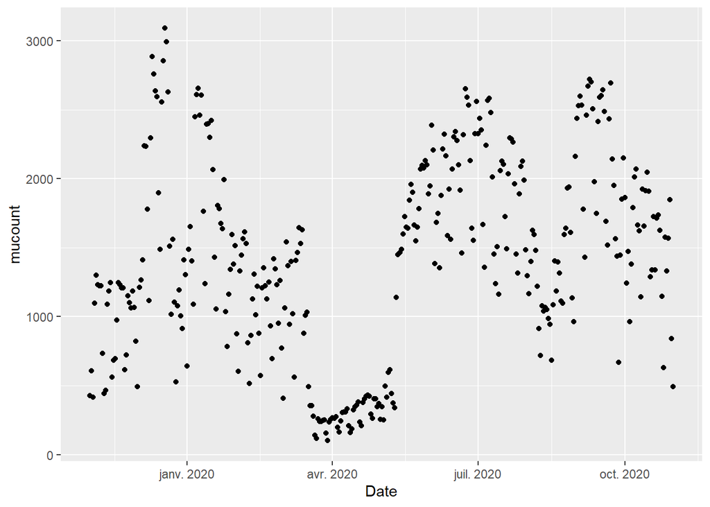

```r
moyc<-data%>%filter(Sensor_type=="full")%>%group_by(Date)%>%summarise(mucount=mean(Bike_count),.groups="drop_last")
ggplot(data=moyc)+geom_point(mapping=aes(x=Date,y=mucount))
```

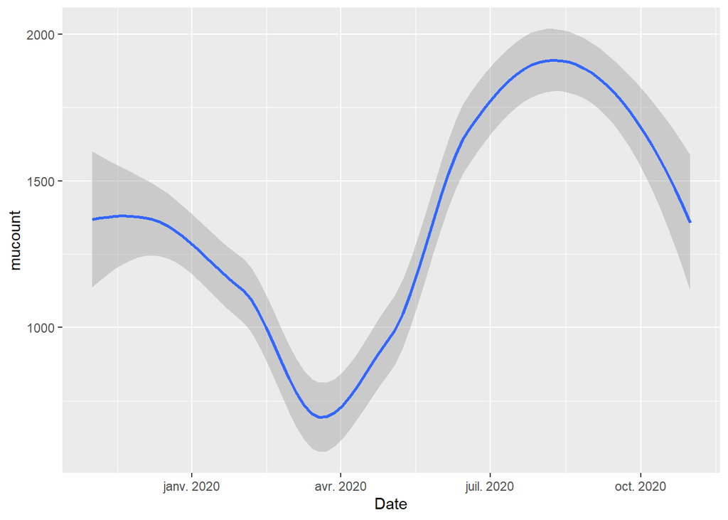

```r
ggplot(data=moyc)+geom_smooth(mapping=aes(x=Date,y=mucount))
```

Describe the trend(s) you observe. Do they change when you average over all sensors (including partial sensors)? Illustrate your answer with a graphic.

Plotting the daily counts over time in a smooth geom gives an easier to read and informative graph on the general trends of daily bikecounts. Here, as there are fewer than a 1000 observations, geom_smooth uses a LOESS regression, which is a kind of regression building on the least square method we saw in Tristan’s lecture, and a formula of `y~x`.

An interesting note is that the regression makes the May spike appear way more impressive than it seems in a scatter plot.

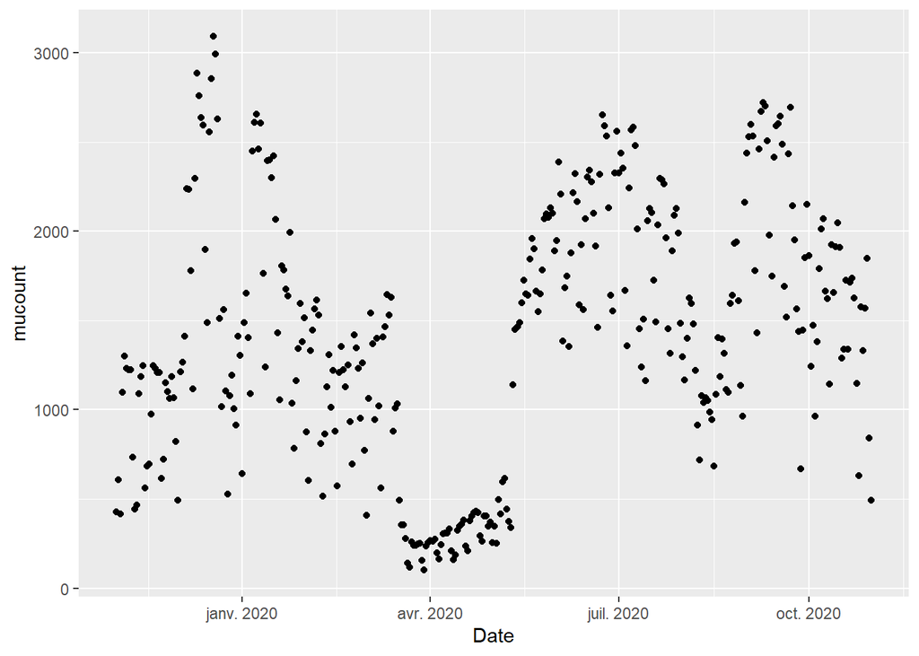

```r
moycall<-data%>%group_by(Date)%>%summarise(mucount=mean(Bike_count),.groups="drop_last")
ggplot(data=moyc)+geom_point(mapping=aes(x=Date,y=mucount))
```

## Comparison (4 pt)

It is often claimed that there are more bike on the roads in summer than in winter. Using only full sensors, test that claim. Do not average over sensors but use all sensors instead. Write down the hypothesis you test and justify the test you use.

```r
fs<-data%>%filter(Sensor_type=="full")%>%filter(Season=="summer"|Season=="winter")
#View(fs)
var.test(Bike_count~Season,data=fs)
```

```
##
##  F test to compare two variances
##
## data:  Bike_count by Season
## F = 1.7285, num df = 4887, denom df = 4679, p-value < 2.2e-16
## alternative hypothesis: true ratio of variances is not equal to 1
## 95 percent confidence interval:
##  1.633170 1.829281
## sample estimates:
## ratio of variances
##           1.728477
```

```r
t.test(Bike_count~Season,data=fs)
```

```
##
##  Welch Two Sample t-test
##
## data:  Bike_count by Season
## t = 20.258, df = 9105.1, p-value < 2.2e-16
## alternative hypothesis: true difference in means is not equal to 0
## 95 percent confidence interval:
##  475.5178 577.4041
## sample estimates:
## mean in group summer mean in group winter
##             1830.484             1304.023
```

Comment the result and plot a graph that illustrate this:

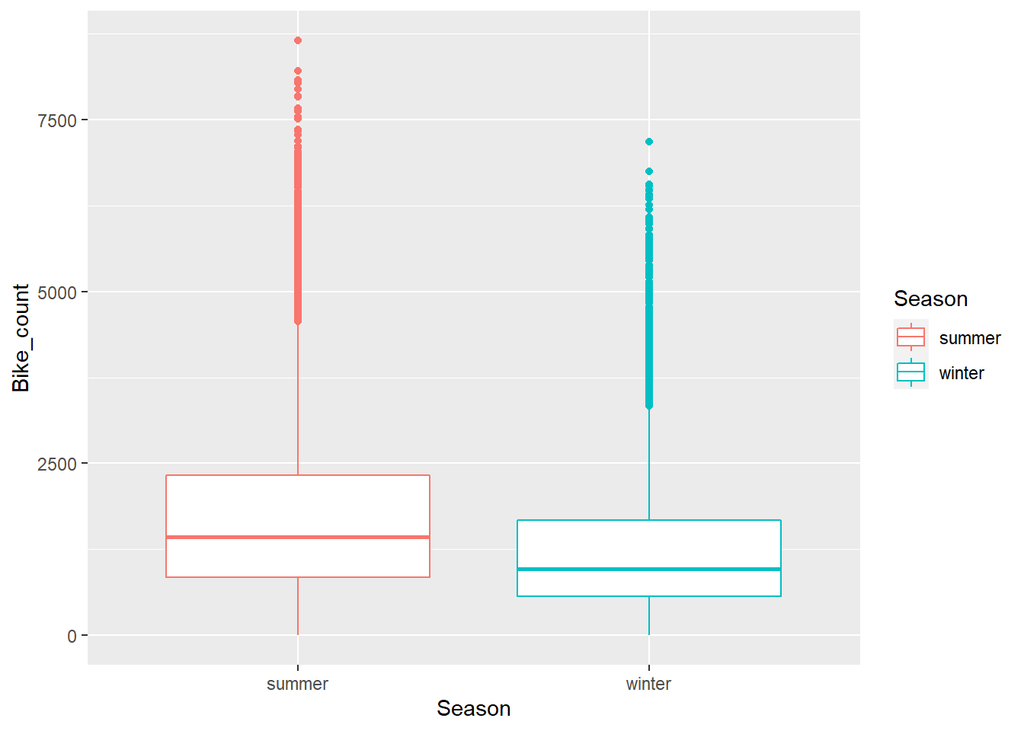

```r
ggplot(data=fs)+geom_boxplot(mapping=aes(x=Season,y=Bike_count,color=Season))
```

What are the limits of the approach you used? What better model could you use?

# Comparing opposed flows at a given sensor (4 pt)

Consider the 2 locations closest to CRI: `Totem 64 Rue de Rivoli` and `152 boulevard du Montparnasse`. Both locations have two sensors: one measuring the bike flow running East to West (with suffix E-O) and one measuring the flow running West to East (with suffix O-E).

We want to know if:

- if the two bike flows are similar in Rue de Rivoli
- if the two bike flows are similar in boulevard du Montparnasse
- if the proportion of the E-O flow in the total flow (E-O flow + O-E flow) is the same in both locations.

Compute the total number of bikes for each of the four mentioned sensors.

```r
#create one dataframe for each set of two directional sensors we're interested in
riv<-data%>%filter(Location_name=="Totem 64 Rue de Rivoli")
mtp<-data%>%filter(Location_name=="152 boulevard du Montparnasse")
#create a Direction column, essentially useless but can be used to make tidyer graph legends
riv<-riv%>%mutate(Direction=ifelse(Name=="Totem 64 Rue de Rivoli O-E","O-E","E-O"))
mtp<-mtp%>%mutate(Direction=ifelse(Name=="152 boulevard du Montparnasse O-E","O-E","E-O"))
locs<-bind_rows(riv,mtp)
mt<-locs%>%group_by(Name)%>%summarise(avgbc=mean(Bike_count),.groups="drop_last")
mt
```

```
## # A tibble: 4 x 2
##   Name                              avgbc
##   <chr>                             <dbl>
## 1 152 boulevard du Montparnasse E-O 1017.
## 2 152 boulevard du Montparnasse O-E  902.
## 3 Totem 64 Rue de Rivoli E-O        2570.
## 4 Totem 64 Rue de Rivoli O-E        3692.
```

Use those numbers to answer the previous questions. Write down the hypothesis you test and justify the test you use.

```r
var.test(Bike_count~Name,data=riv)
```

```
##
##  F test to compare two variances
##
## data:  Bike_count by Name
## F = 0.31325, num df = 365, denom df = 365, p-value < 2.2e-16
## alternative hypothesis: true ratio of variances is not equal to 1
## 95 percent confidence interval:
##  0.2550587 0.3847109
## sample estimates:
## ratio of variances
##          0.3132473
```

```r
t.test(Bike_count~Name,data=riv)
```

```
##
##  Welch Two Sample t-test
##
## data:  Bike_count by Name
## t = -8.8598, df = 573.24, p-value < 2.2e-16
## alternative hypothesis: true difference in means is not equal to 0
## 95 percent confidence interval:
##  -1370.4965  -873.1155
## sample estimates:
## mean in group Totem 64 Rue de Rivoli E-O
##                                 2570.180
## mean in group Totem 64 Rue de Rivoli O-E
##                                 3691.986
```

```r
var.test(Bike_count~Name,data=mtp)
```

```
##
##  F test to compare two variances
##
## data:  Bike_count by Name
## F = 1.2549, num df = 365, denom df = 365, p-value = 0.03036
## alternative hypothesis: true ratio of variances is not equal to 1
## 95 percent confidence interval:
##  1.021818 1.541231
## sample estimates:
## ratio of variances
##           1.254933
```

```r
t.test(Bike_count~Name,data=mtp)
```

```
##
##  Welch Two Sample t-test
##
## data:  Bike_count by Name
## t = 3.1738, df = 720.79, p-value = 0.001568
## alternative hypothesis: true difference in means is not equal to 0
## 95 percent confidence interval:
##   44.09003 187.09576
## sample estimates:
## mean in group 152 boulevard du Montparnasse E-O
##                                        1017.481
## mean in group 152 boulevard du Montparnasse O-E
##                                         901.888
```

```r
rivs<-riv%>%group_by(Name)%>%summarise(bc=sum(Bike_count),.groups="drop_last")%>%mutate(tot=sum(bc))
mtps<-mtp%>%group_by(Name)%>%summarise(bc=sum(Bike_count),.groups="drop_last")%>%mutate(tot=sum(bc))
bind_rows(rivs,mtps)
```

```
## # A tibble: 4 x 3
##   Name                                   bc     tot
##   <chr>                               <dbl>   <dbl>
## 1 Totem 64 Rue de Rivoli E-O         940686 2291953
## 2 Totem 64 Rue de Rivoli O-E        1351267 2291953
## 3 152 boulevard du Montparnasse E-O  372398  702489
## 4 152 boulevard du Montparnasse O-E  330091  702489
```

```r
prop.test(c(rivs$bc[1],mtps$bc[1]),c(rivs$tot[1],mtps$tot[1]))
```

```
##
##  2-sample test for equality of proportions with continuity correction
##
## data:  c(rivs$bc[1], mtps$bc[1]) out of c(rivs$tot[1], mtps$tot[1])
## X-squared = 31280, df = 1, p-value < 2.2e-16
## alternative hypothesis: two.sided
## 95 percent confidence interval:
##  -0.1210128 -0.1183519
## sample estimates:
##    prop 1    prop 2
## 0.4104299 0.5301122
```

Plot a graph illustrating the results you observed

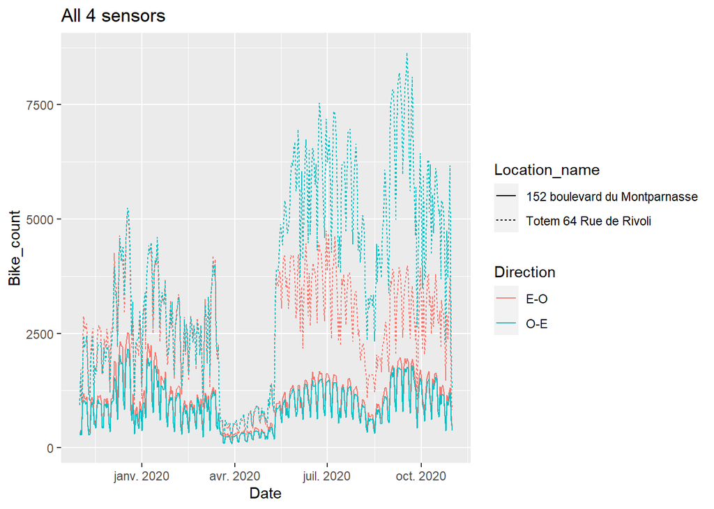

```r
ggplot(data=locs)+geom_line(mapping=aes(x=Date,y=Bike_count,color=Direction,linetype=Location_name))+ggtitle("All 4 sensors")
```

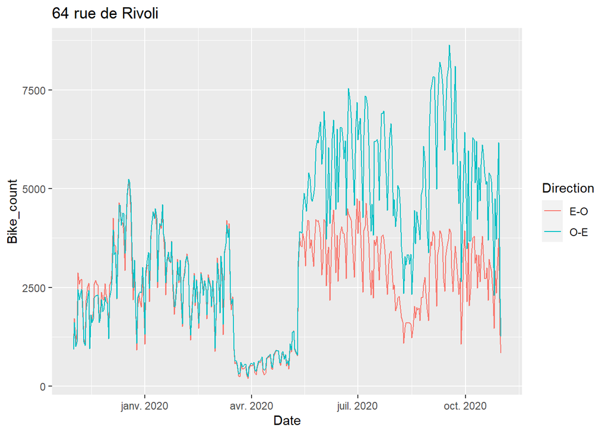

```r
ggplot(data=riv)+geom_line(mapping=aes(x=Date,y=Bike_count,color=Direction))+ggtitle("64 rue de Rivoli")
```

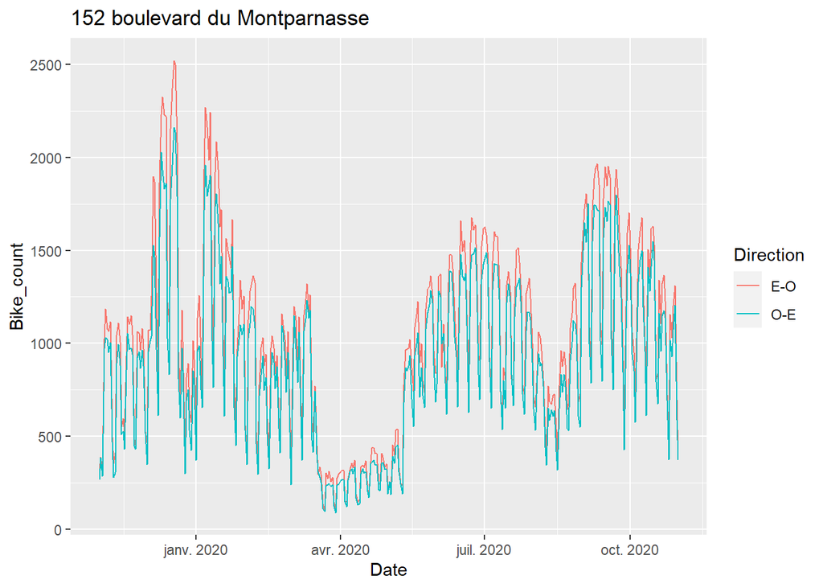

```r
ggplot(data=mtp)+geom_line(mapping=aes(x=Date,y=Bike_count,color=Direction))+ggtitle("152 boulevard du Montparnasse")
```

# Creative space (4 pt)

Suggest an interesting visualisation and/or answer an interesting question using the data at hand

We are pretty curious as to why the proportion of westwards traffic is lower in the Totem 64 rue de Rivoli data.

Maybe it’s Paris’ topography?

It’s not the data at hand per se, but the open data initiative of the city of Paris also delivers measurements of height relative to sea level at 1664134 points according to the General Levelling of France (NGF) network, in the `plan-de-voirie-points-de-nivellement-etiquettes` dataset. The plan was to construct a heatmap of paris altitude with ggplot2, and try to see whether or not the fact that more bikes went eastwards was due to it being a downhill ride. However, as the sheer size of the dataset kept crashing R, and this hypothesis seemed unlikely, we gave up. A solution for working with the data might have been to make a proper json request to the server’s API, but this did not seem very relevant to the question.

A quick look at the [description of sensors used](https://www.eco-compteur.com/produits/gamme-zelt/zelt-urbaine/) given by the company in charge of the deployment in Paris tells us that the data relies on the “magnetic signature of each bike wheel”, and that the measures are generally taken by a belt that reaches a maximum of 1.5 meters of length. Knowing how there is two sensors at this location (O-E and E-O), and that the cycling lane is 4m wide, everything checks out. However, since the “déconfinement” on the 11/05/2020, the rue de Rivoli has been [partially cut from car traffic](https://www.lemonde.fr/m-le-mag/article/2020/05/29/la-rue-rivoli-a-paris-champ-de-batailles_6041192_4500055.html). This means that, as can be seen on the image presented on this article, the lane previously reserved to automobiles has been allocated to the bike flow. As this was not the case when the sensor was put in place (2019-09-04 according to our `sensors` dataframe), the bikes passing on this newly opened lane could not have been measured by the sensors. The direction getting the lesser proportion seems to check out with that hypothesis, as this new lane allows westward traffic.

Let’s investigate this hypothesis with our R skills.

First, we’ll create a column in our dataframe representing the confinment status.

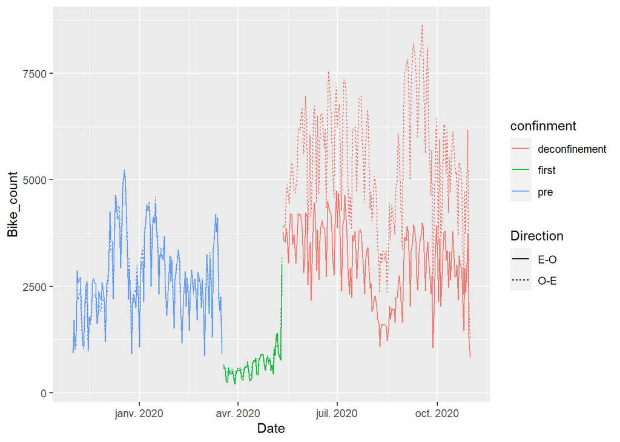

```r
riv<-data%>%filter(Location_name=="Totem 64 Rue de Rivoli")
riv<-riv%>%mutate(Direction=ifelse(Name=="Totem 64 Rue de Rivoli O-E","O-E","E-O"))
riv<- riv %>% mutate(
  confinment = case_when(
    Date <= as.Date("2020-03-17")                                 ~ "pre",
    Date >= as.Date("2020-03-17") & Date <= as.Date("2020-05-11") ~ "first",
    Date >= as.Date("2020-05-11")                                 ~ "deconfinement",
  )
)
ggplot(data=riv)+geom_line(mapping=aes(x=Date,y=Bike_count,linetype=Direction,color=confinment))
```

We’ll then repeat the prop.test done in the previous comparison, but grouping by confinment rather than direction.

```r
rivp<-riv%>%filter(confinment=="pre")
rivf<-riv%>%filter(confinment=="first")
rivd<-riv%>%filter(confinment=="deconfinement")
rivps<-rivp%>%group_by(Name)%>%summarise(bc=sum(Bike_count),.groups="drop_last")%>%mutate(tot=sum(bc))
rivfs<-rivf%>%group_by(Name)%>%summarise(bc=sum(Bike_count),.groups="drop_last")%>%mutate(tot=sum(bc))
rivds<-rivd%>%group_by(Name)%>%summarise(bc=sum(Bike_count),.groups="drop_last")%>%mutate(tot=sum(bc))
bind_rows(rivps,rivfs,rivds)
```

```
## # A tibble: 6 x 3
##   Name                           bc     tot
##   <chr>                       <dbl>   <dbl>
## 1 Totem 64 Rue de Rivoli E-O 373294  747763
## 2 Totem 64 Rue de Rivoli O-E 374469  747763
## 3 Totem 64 Rue de Rivoli E-O  36375   75238
## 4 Totem 64 Rue de Rivoli O-E  38863   75238
## 5 Totem 64 Rue de Rivoli E-O 531017 1468952
## 6 Totem 64 Rue de Rivoli O-E 937935 1468952
```

```r
Bikecount_deconfinement_EO<-rivds$bc[1]
Bikecount_first_EO<-rivfs$bc[1]
Bikecount_pre_EO<-rivps$bc[1]
Total_Bikecount_pre<-rivps$tot[1]
Total_Bikecount_first<-rivfs$tot[1]
Total_Bikecount_deconfinement<-rivds$tot[1]
prop.test(c(Bikecount_pre_EO,Bikecount_first_EO,Bikecount_deconfinement_EO),c(Total_Bikecount_pre,Total_Bikecount_first,Total_Bikecount_deconfinement))
```

```
##
##  3-sample test for equality of proportions without continuity
##  correction
##
## data:  c(Bikecount_pre_EO, Bikecount_first_EO, Bikecount_deconfinement_EO) out of c(Total_Bikecount_pre, Total_Bikecount_first, Total_Bikecount_deconfinement)
## X-squared = 40555, df = 2, p-value < 2.2e-16
## alternative hypothesis: two.sided
## sample estimates:
##    prop 1    prop 2    prop 3
## 0.4992143 0.4834658 0.3614938
```

Our hypothesis seems to hold, we’ve got a clear decrease in the proportion of westwards bikecount since 11.05.2020.